# HW2

Jackson Evans

3/21/2021

4.2)

```r
population<- c(3,6,7,9,11,14)

library(gtools)

perms<-permutations(6,3,population)
mins<-NULL
for(i in 1:120){
  mins[i]<-min(perms[i,1],perms[i,2],perms[i,3])
}
mean(mins)
```

```
## [1] 4.8
```

The parameter is the mean of mins of every permutation of the population. This value, calculated above, is 4.8.

4.18) a) By theorem B.6.2, when X1, X2,…,Xn are independent Poisson random variables, the sampling distribution X=X1+X2+…+Xn is Pois(sum of lambdas). Therefore W=Pois(19).

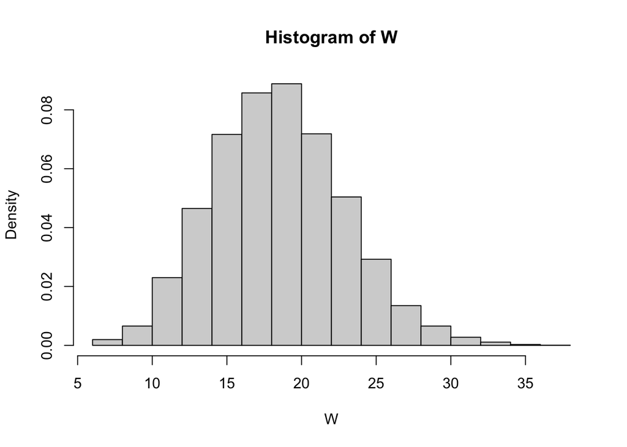

```r
set.seed((123))
X<-rpois(10^4,4)
Y<-rpois(10^4,12)
U<-rpois(10^4,3)
W<-X+Y+U
hist(W, prob=TRUE)
```

```r
#mean:
mean(W)
```

```
## [1] 18.974
```

```r
#standard deviation:
sqrt(var(W))
```

```
## [1] 4.409815
```

The theoretical mean is 19, and the theoretical standard deviation for a Poisson random variable is the square root of the mean = sqrt(19) = 4.35. Both values are very close approximations: our simulated mean is 18.974 and our simulated standard deviation is 4.409815.

```r
set.seed((123))
X<-rpois(10^4,4)
Y<-rpois(10^4,12)
U<-rpois(10^4,3)
W<-X+Y+U

#Based on the simulated sampling distribution from b
mean(W<=14)
```

```
## [1] 0.156
```

```r
#P(W<=14 is approximately 0.156)

#Exact calculation is:
ppois(14,19)
```

```
## [1] 0.1497495
```

```r
#So the estimation is very close
```

4.20) a) Working out scanned and submitted. W = Xbar - Ybar = N(-3, (1.755942)^2)

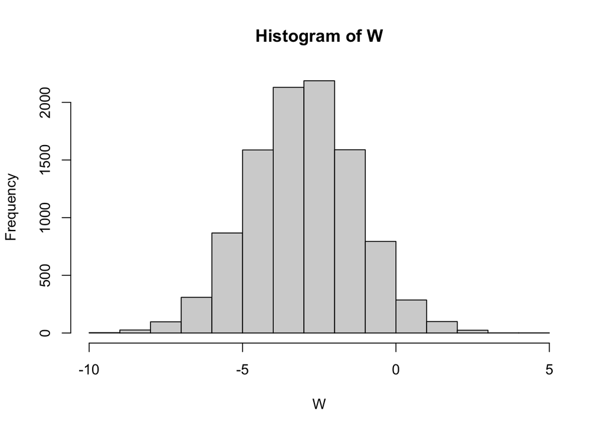

```r
set.seed(123456)

W<-numeric(10000)
for(i in 1:10000){
  x<- rnorm(9, 7, 3)
  y<- rnorm(12, 10, 5)
  W[i]<- mean(x) - mean(y)
}
hist(W)
```

```r
#simulated mean
sim_mean<-mean(W)
sim_mean
```

```
## [1] -3.02446
```

```r
#simulated sd
sim_sd<-sd(W)
sim_sd
```

```
## [1] 1.756511
```

Our simulated mean is -3.02446, very close to the actual mean of -3. Our simulated standard deviation is 1.756511, very close to the actual standard deviation of 1.755924.

```r
set.seed(123456)

W<-numeric(10000)
for(i in 1:10000){
  x<- rnorm(9, 7, 3)
  y<- rnorm(12, 10, 5)
  W[i]<- mean(x) - mean(y)
}
sim_c<-mean(W< -1.5)
sim_c #simulated P(W <= -1.5)
```

```
## [1] 0.808
```

```r
pnorm(-1.5, -3, sqrt(3^2/9 + 5^2/12), lower.tail=TRUE) #exact
```

```
## [1] 0.8035146
```

Our sumulated value for P(W < -1.5) is 0.808, while our exact value is 0.8035146. These are very close.

4.27) Handwritten and uploaded alongside this document.

10.2) a) Is there a difference in attempts at low-fat diets betweenwomen and men? Let’s assume we have a random sample of both women and men. H0: Proportions of women and men trying and not trying a low-fat diet are the same. H1: There is a difference in trying low-fat diets based on sex.

```r
# Total yes: 43. Total no: 243.
# Total Women: 181. Total Men: 105.
#Proportion of Women is 181/286. Men is 105/286.
#Expected in each cell:
#Women, Yes = 181/286 * 43 = 27.21329
w_y <- 181/286 * 43
w_y
```

```
## [1] 27.21329
```

```r
#Women, No = 181/286 * 243 = 153.7867
w_n <- 181/286 * 243
w_n
```

```
## [1] 153.7867
```

```r
#Men, Yes = 105/286 * 43 = 15.78671
m_y <- 105/286 * 43
m_y
```

```
## [1] 15.78671
```

```r
#Men, No = 105/286 * 243 = 89.21329
m_n <- 105/286 * 243
m_n
```

```
## [1] 89.21329
```

Women, Yes = 181/286 * 43 = 27.21329 Women, No = 181/286 * 243 = 153.7867 Men, Yes = 105/286 * 43 = 15.78671 Men, No = 105/286 * 243 = 89.21329

```r
w_y <- 181/286 * 43
w_n <- 181/286 * 243
m_y <- 105/286 * 43
m_n <- 105/286 * 243

cell1_stat<- (35-w_y)^2 /w_y
cell2_stat<- (146-w_n)^2 /w_n
cell3_stat<- (8-m_y)^2 /m_y
cell4_stat<- (97-m_n)^2 /m_n
statistic <- cell1_stat+cell2_stat+cell3_stat+cell4_stat
statistic
```

```
## [1] 7.142724
```

```r
1 - pchisq(statistic, 4)
```

```
## [1] 0.1285354
```

Our statistic is 7.142724. Our p-value is 0.1285, which is not significant enough to conclude a distinction between sex and attempts at a low-fat diet.

4. No, the data are taken from college students, which is not representative for a population. Furthermore, the p-value was not strong enough to draw conclusions to reject the null hypothesis.

10.3) Is there a difference in response to enhancement between the races white and black and the ethnicity hispanic? Let’s assume we have a random sample of black people, white people and hispanic people. H0: proportions of responses of black people, hispanic people and white people to enhancement are the same. H1: there is a difference in response to enhancement based on race/ethnicity.

```r
white_values_final <- c(rep("Morally acceptable", 829),
                          rep("Morally unacceptable", 1262),
                          rep("Not sure", 1442))

black_values_final <- c(rep("Morally acceptable", 57),
                          rep("Morally unacceptable", 126),
                          rep("Not sure", 215))

hispanic_values_final <- c(rep("Morally acceptable", 79),
                        rep("Morally unacceptable", 136),
                        rep("Not sure", 159))

#Make a data set
enhance_data_final <- data.frame(race_ethnicity = c(rep("White", 3533),
                                           rep("Black", 398),
                                           rep("Hispanic", 374)),
                                response = c(white_values_final,
                                               black_values_final,
                                               hispanic_values_final))


observed<-table(enhance_data_final)

col.sums <- colSums(observed)
row.sums <- rowSums(observed)
grand.sum <- nrow(enhance_data_final)

row.matrix <- matrix(row.sums, ncol = 1)
col.matrix <- matrix(col.sums, ncol = 1)

#Expected values:
row.matrix %*% t(col.matrix) / grand.sum
```

```
##           [,1]      [,2]      [,3]
## [1,]  89.21487  140.8948  167.8904
## [2,]  83.83508  132.3986  157.7663
## [3,] 791.95006 1250.7066 1490.3433
```

Rows sorted alphabetically: Black, Hispanic, White. These are the expected values.

```r
white_values_final <- c(rep("Morally acceptable", 829),
                        rep("Morally unacceptable", 1262),
                        rep("Not sure", 1442))

black_values_final <- c(rep("Morally acceptable", 57),
                        rep("Morally unacceptable", 126),
                        rep("Not sure", 215))

hispanic_values_final <- c(rep("Morally acceptable", 79),
                           rep("Morally unacceptable", 136),
                           rep("Not sure", 159))

#Make a data set
enhance_data_final <- data.frame(race_ethnicity = c(rep("White", 3533),
                                                    rep("Black", 398),
                                                    rep("Hispanic", 374)),
                                 response = c(white_values_final,
                                              black_values_final,
                                              hispanic_values_final))


actual<-table(enhance_data_final)
col.sums <- colSums(actual)
row.sums <- rowSums(actual)
grand.sum <- nrow(enhance_data_final)

row.matrix <- matrix(row.sums, ncol = 1)
col.matrix <- matrix(col.sums, ncol = 1)

expected<-row.matrix %*% t(col.matrix) / grand.sum

#Chi-square contribution
chi.sq.cont <- (actual - expected)^2/expected

#Sum up our chi-square contributions. Our statistic is:
sum(chi.sq.cont)
```

```
## [1] 30.21593
```

```r
#Therefore our p-value is:
1 - pchisq(sum(chi.sq.cont), 4)
```

```
## [1] 4.423186e-06
```

```r
proportions<-c(actual[1]/398, actual[4]/398, actual[7]/398,
               actual[2]/374, actual[5]/374, actual[8]/374,
               actual[3]/3533, actual[6]/3533, actual[9]/3533)
```